# Risk Factor Analysis

## Outcome Variable

**Outcome Variable:** s03rec24

## Predictor Variables

**Intervention Variable:** mhtcm

**Adjustment Set:**

unadjusted

## Stratifying Variables

The analysis was stratified on these variable(s):

- studyid
- country

## Data Summary

| studyid | country | mhtcm | s03rec24 | n_cell | n |
| --- | --- | --- | --- | --- | --- |
| ki0047075b-MAL-ED | BANGLADESH | >=155 cm | 0 | 24 | 241 |
| ki0047075b-MAL-ED | BANGLADESH | >=155 cm | 1 | 1 | 241 |
| ki0047075b-MAL-ED | BANGLADESH | <151 cm | 0 | 149 | 241 |
| ki0047075b-MAL-ED | BANGLADESH | <151 cm | 1 | 5 | 241 |
| ki0047075b-MAL-ED | BANGLADESH | [151-155) cm | 0 | 60 | 241 |
| ki0047075b-MAL-ED | BANGLADESH | [151-155) cm | 1 | 2 | 241 |
| ki0047075b-MAL-ED | BRAZIL | >=155 cm | 0 | 116 | 214 |
| ki0047075b-MAL-ED | BRAZIL | >=155 cm | 1 | 10 | 214 |
| ki0047075b-MAL-ED | BRAZIL | <151 cm | 0 | 43 | 214 |
| ki0047075b-MAL-ED | BRAZIL | <151 cm | 1 | 6 | 214 |
| ki0047075b-MAL-ED | BRAZIL | [151-155) cm | 0 | 37 | 214 |
| ki0047075b-MAL-ED | BRAZIL | [151-155) cm | 1 | 2 | 214 |
| ki0047075b-MAL-ED | INDIA | >=155 cm | 0 | 53 | 238 |
| ki0047075b-MAL-ED | INDIA | >=155 cm | 1 | 2 | 238 |
| ki0047075b-MAL-ED | INDIA | <151 cm | 0 | 109 | 238 |
| ki0047075b-MAL-ED | INDIA | <151 cm | 1 | 5 | 238 |
| ki0047075b-MAL-ED | INDIA | [151-155) cm | 0 | 63 | 238 |
| ki0047075b-MAL-ED | INDIA | [151-155) cm | 1 | 6 | 238 |
| ki0047075b-MAL-ED | NEPAL | >=155 cm | 0 | 38 | 237 |
| ki0047075b-MAL-ED | NEPAL | >=155 cm | 1 | 3 | 237 |
| ki0047075b-MAL-ED | NEPAL | <151 cm | 0 | 129 | 237 |
| ki0047075b-MAL-ED | NEPAL | <151 cm | 1 | 3 | 237 |
| ki0047075b-MAL-ED | NEPAL | [151-155) cm | 0 | 59 | 237 |
| ki0047075b-MAL-ED | NEPAL | [151-155) cm | 1 | 5 | 237 |
| ki0047075b-MAL-ED | PERU | >=155 cm | 0 | 52 | 272 |
| ki0047075b-MAL-ED | PERU | >=155 cm | 1 | 7 | 272 |
| ki0047075b-MAL-ED | PERU | <151 cm | 0 | 150 | 272 |
| ki0047075b-MAL-ED | PERU | <151 cm | 1 | 7 | 272 |
| ki0047075b-MAL-ED | PERU | [151-155) cm | 0 | 51 | 272 |
| ki0047075b-MAL-ED | PERU | [151-155) cm | 1 | 5 | 272 |
| ki0047075b-MAL-ED | SOUTH AFRICA | >=155 cm | 0 | 186 | 264 |
| ki0047075b-MAL-ED | SOUTH AFRICA | >=155 cm | 1 | 14 | 264 |
| ki0047075b-MAL-ED | SOUTH AFRICA | <151 cm | 0 | 29 | 264 |
| ki0047075b-MAL-ED | SOUTH AFRICA | <151 cm | 1 | 3 | 264 |
| ki0047075b-MAL-ED | SOUTH AFRICA | [151-155) cm | 0 | 31 | 264 |
| ki0047075b-MAL-ED | SOUTH AFRICA | [151-155) cm | 1 | 1 | 264 |
| ki0047075b-MAL-ED | TANZANIA, UNITED REPUBLIC OF | >=155 cm | 0 | 149 | 248 |
| ki0047075b-MAL-ED | TANZANIA, UNITED REPUBLIC OF | >=155 cm | 1 | 0 | 248 |
| ki0047075b-MAL-ED | TANZANIA, UNITED REPUBLIC OF | <151 cm | 0 | 48 | 248 |
| ki0047075b-MAL-ED | TANZANIA, UNITED REPUBLIC OF | <151 cm | 1 | 0 | 248 |
| ki0047075b-MAL-ED | TANZANIA, UNITED REPUBLIC OF | [151-155) cm | 0 | 50 | 248 |
| ki0047075b-MAL-ED | TANZANIA, UNITED REPUBLIC OF | [151-155) cm | 1 | 1 | 248 |
| ki1017093b-PROVIDE | BANGLADESH | >=155 cm | 0 | 134 | 660 |
| ki1017093b-PROVIDE | BANGLADESH | >=155 cm | 1 | 4 | 660 |
| ki1017093b-PROVIDE | BANGLADESH | <151 cm | 0 | 352 | 660 |
| ki1017093b-PROVIDE | BANGLADESH | <151 cm | 1 | 13 | 660 |
| ki1017093b-PROVIDE | BANGLADESH | [151-155) cm | 0 | 152 | 660 |
| ki1017093b-PROVIDE | BANGLADESH | [151-155) cm | 1 | 5 | 660 |
| ki1066203-TanzaniaChild2 | TANZANIA, UNITED REPUBLIC OF | >=155 cm | 0 | 1427 | 2244 |
| ki1066203-TanzaniaChild2 | TANZANIA, UNITED REPUBLIC OF | >=155 cm | 1 | 1 | 2244 |
| ki1066203-TanzaniaChild2 | TANZANIA, UNITED REPUBLIC OF | <151 cm | 0 | 329 | 2244 |
| ki1066203-TanzaniaChild2 | TANZANIA, UNITED REPUBLIC OF | <151 cm | 1 | 0 | 2244 |
| ki1066203-TanzaniaChild2 | TANZANIA, UNITED REPUBLIC OF | [151-155) cm | 0 | 486 | 2244 |
| ki1066203-TanzaniaChild2 | TANZANIA, UNITED REPUBLIC OF | [151-155) cm | 1 | 1 | 2244 |
| ki1101329-Keneba | GAMBIA | >=155 cm | 0 | 1774 | 2189 |
| ki1101329-Keneba | GAMBIA | >=155 cm | 1 | 43 | 2189 |
| ki1101329-Keneba | GAMBIA | <151 cm | 0 | 78 | 2189 |
| ki1101329-Keneba | GAMBIA | <151 cm | 1 | 5 | 2189 |
| ki1101329-Keneba | GAMBIA | [151-155) cm | 0 | 274 | 2189 |
| ki1101329-Keneba | GAMBIA | [151-155) cm | 1 | 15 | 2189 |

The following strata were considered:

- studyid: ki0047075b-MAL-ED, country: BANGLADESH
- studyid: ki0047075b-MAL-ED, country: BRAZIL
- studyid: ki0047075b-MAL-ED, country: INDIA
- studyid: ki0047075b-MAL-ED, country: NEPAL
- studyid: ki0047075b-MAL-ED, country: PERU
- studyid: ki0047075b-MAL-ED, country: SOUTH AFRICA
- studyid: ki0047075b-MAL-ED, country: TANZANIA, UNITED REPUBLIC OF
- studyid: ki1017093b-PROVIDE, country: BANGLADESH
- studyid: ki1066203-TanzaniaChild2, country: TANZANIA, UNITED REPUBLIC OF
- studyid: ki1101329-Keneba, country: GAMBIA

### Dropped Strata

Some strata were dropped due to rare outcomes:

- studyid: ki0047075b-MAL-ED, country: BANGLADESH
- studyid: ki0047075b-MAL-ED, country: BRAZIL
- studyid: ki0047075b-MAL-ED, country: INDIA
- studyid: ki0047075b-MAL-ED, country: NEPAL
- studyid: ki0047075b-MAL-ED, country: SOUTH AFRICA
- studyid: ki0047075b-MAL-ED, country: TANZANIA, UNITED REPUBLIC OF
- studyid: ki1017093b-PROVIDE, country: BANGLADESH
- studyid: ki1066203-TanzaniaChild2, country: TANZANIA, UNITED REPUBLIC OF

## Methods Detail

We’re interested in the causal parameters $E[Y_a]$ for all values of $a \in \mathcal{A}$. These parameters represent the mean outcome if, possibly contrary to fact, we intervened to set all units to have $A=a$. Under the randomization and positivity assumptions, these are identified by the statistical parameters $\psi_a=E_W[E_{Y|A,W}(Y|A=a,W)]$. In addition, we’re interested in the mean of $Y$, $E[Y]$ under no intervention (the observed mean). We will estimate these parameters by using SuperLearner to fit the relevant likelihood factors – $E_{Y|A,W}(Y|A=a,W)$ and $p(A=a|W)$, and then updating our likelihood fit using a joint TMLE.

For unadjusted analyses ($W=\{\}$), initial likelihoods were estimated using Lrnr_glm to estimate the simple $E(Y|A)$ and Lrnr_mean to estimate $p(A)$. For adjusted analyses, a small library containing Lrnr_glmnet, Lrnr_xgboost, and Lrnr_mean was used.

Having estimated these parameters, we will then use the delta method to estimate relative risks and attributable risks relative to a prespecified baseline level of $A$.

# Results Detail

## Results Plots

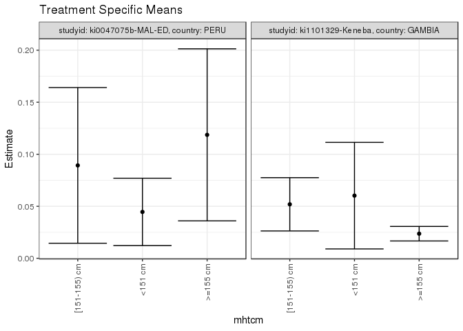

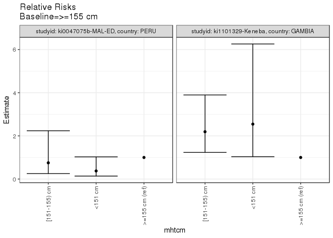

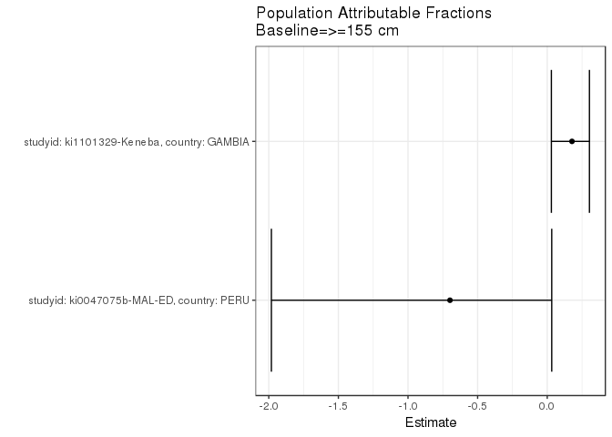

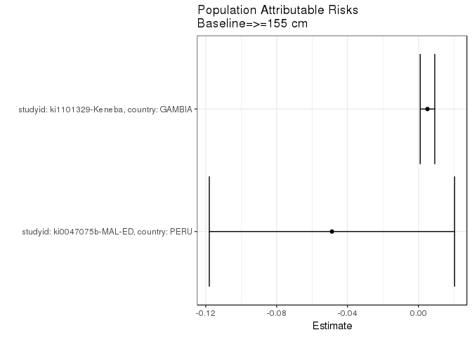

## Results Table

### Parameter: TSM

| studyid | country | intervention_level | baseline_level | estimate | ci_lower | ci_upper |
| --- | --- | --- | --- | --- | --- | --- |
| ki0047075b-MAL-ED | PERU | >=155 cm | NA | 0.1186441 | 0.0359793 | 0.2013089 |
| ki0047075b-MAL-ED | PERU | <151 cm | NA | 0.0445860 | 0.0122420 | 0.0769299 |
| ki0047075b-MAL-ED | PERU | [151-155) cm | NA | 0.0892857 | 0.0144626 | 0.1641089 |
| ki1101329-Keneba | GAMBIA | >=155 cm | NA | 0.0236654 | 0.0166746 | 0.0306562 |
| ki1101329-Keneba | GAMBIA | <151 cm | NA | 0.0602410 | 0.0090418 | 0.1114401 |
| ki1101329-Keneba | GAMBIA | [151-155) cm | NA | 0.0519031 | 0.0263219 | 0.0774843 |

### Parameter: E(Y)

| studyid | country | intervention_level | baseline_level | estimate | ci_lower | ci_upper |
| --- | --- | --- | --- | --- | --- | --- |
| ki0047075b-MAL-ED | PERU | NA | NA | 0.0698529 | 0.0395048 | 0.1002010 |
| ki1101329-Keneba | GAMBIA | NA | NA | 0.0287803 | 0.0217749 | 0.0357856 |

### Parameter: RR

| studyid | country | intervention_level | baseline_level | estimate | ci_lower | ci_upper |
| --- | --- | --- | --- | --- | --- | --- |
| ki0047075b-MAL-ED | PERU | >=155 cm | >=155 cm | 1.0000000 | 1.0000000 | 1.000000 |
| ki0047075b-MAL-ED | PERU | <151 cm | >=155 cm | 0.3757962 | 0.1374435 | 1.027497 |
| ki0047075b-MAL-ED | PERU | [151-155) cm | >=155 cm | 0.7525510 | 0.2530629 | 2.237914 |
| ki1101329-Keneba | GAMBIA | >=155 cm | >=155 cm | 1.0000000 | 1.0000000 | 1.000000 |
| ki1101329-Keneba | GAMBIA | <151 cm | >=155 cm | 2.5455310 | 1.0351651 | 6.259608 |
| ki1101329-Keneba | GAMBIA | [151-155) cm | >=155 cm | 2.1932083 | 1.2346091 | 3.896102 |

### Parameter: PAR

| studyid | country | intervention_level | baseline_level | estimate | ci_lower | ci_upper |
| --- | --- | --- | --- | --- | --- | --- |
| ki0047075b-MAL-ED | PERU | >=155 cm | NA | -0.0487911 | -0.1180006 | 0.0204184 |
| ki1101329-Keneba | GAMBIA | >=155 cm | NA | 0.0051149 | 0.0010143 | 0.0092154 |

### Parameter: PAF

| studyid | country | intervention_level | baseline_level | estimate | ci_lower | ci_upper |
| --- | --- | --- | --- | --- | --- | --- |
| ki0047075b-MAL-ED | PERU | >=155 cm | NA | -0.6984835 | -1.981191 | 0.0323176 |
| ki1101329-Keneba | GAMBIA | >=155 cm | NA | 0.1777219 | 0.029726 | 0.3031439 |